# Assignment_1_econometrics

## Import Data set and Libraries

```r
library(ggplot2)
library(readxl)
library(dplyr)
library(ggrepel)
# Load the dataset
df <- read_excel("~/Desktop/Econometrics Lab/Growth.xlsx")

# View the first few rows to confirm it's loaded correctly
head(df)
```

| country_name | growth | oil | rgdp60 | tradeshare | yearsschool | rev_coups | assasinations |
| --- | --- | --- | --- | --- | --- | --- | --- |
| India | 1.9151679 | 0 | 765.9998 | 0.1405020 | 1.45 | 0.1333333 | 0.8666667 |
| Argentina | 0.6176451 | 0 | 4462.0015 | 0.1566230 | 4.99 | 0.9333333 | 1.9333333 |
| Japan | 4.3047590 | 0 | 2953.9995 | 0.1577032 | 6.71 | 0.0000000 | 0.2000000 |
| Brazil | 2.9300966 | 0 | 1783.9999 | 0.1604051 | 2.89 | 0.1000000 | 0.1000000 |
| United States | 1.7122649 | 0 | 9895.0039 | 0.1608150 | 8.66 | 0.0000000 | 0.4333333 |
| Bangladesh | 0.7082631 | 0 | 951.9998 | 0.2214584 | 0.79 | 0.3064815 | 0.1750000 |

## 1. Scatter Plot Analysis

- Create a scatter plot to examine the relationship between the average annual growth rate & the average trade share for countries in the data set.

Identify any outliers in the data set.Which country stands out as an outlier? - Malta is the outlier

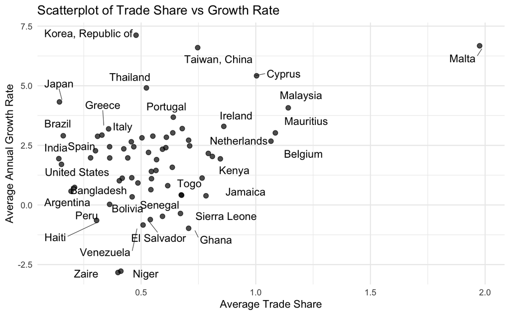

```r
# Create scatterplot
ggplot(df, aes(x = tradeshare, y = growth)) +
  geom_jitter(width = 0.05, height = 0.05, size = 2, alpha = 0.7) +  # Jitter points with transparency

  # Use geom_text_repel to add labels that don't overlap
  geom_text_repel(aes(label = country_name),
                  max.overlaps = 15,  # Allow max 15 labels to overlap before skipping
                  box.padding = 0.5, point.padding = 0.5, segment.size = 0.2) +

  # Add titles and labels
  labs(title = "Scatterplot of Trade Share vs Growth Rate",
       x = "Average Trade Share",
       y = "Average Annual Growth Rate") +
  theme_minimal()
```

## 2. Outlier Identification and Highlighting

Modify your scatter plot to label the countries and highlight the outlier you identified. Which country is highlighted as an outlier? Discuss its significance. - Malta is the outlier due to how far apart it is with all the other points in the graph even though a close one would be the Republic of Korea. Its significant due to the fact it could have an impact on the overall model due to it being so outside of the other countries.

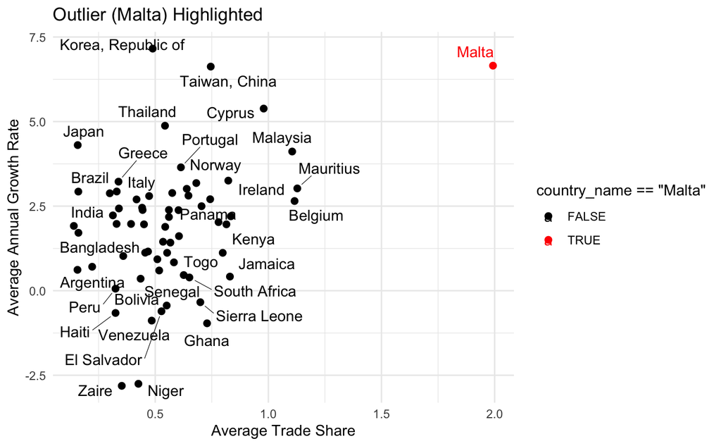

```r
# Highlight Malta as the outlier and prevent label overlap
ggplot(df, aes(x = tradeshare, y = growth, color = country_name == "Malta")) +
  geom_point(size = 2) +  # Make the points larger for better visibility

  # Use geom_text_repel to add country labels and avoid overlap
  geom_text_repel(aes(label = country_name),
                  max.overlaps = 15,  # Allow up to 15 labels to overlap before skipping
                  box.padding = 0.35, point.padding = 0.5, segment.size = 0.2) +  # Adjust padding

  # Highlight the outlier (Malta) in red and other countries in black
  scale_color_manual(values = c("black", "red")) +

  # Add titles and labels
  labs(title = "Outlier (Malta) Highlighted",
       x = "Average Trade Share",
       y = "Average Annual Growth Rate") +
  theme_minimal()
```

## 3. Correlation Investigation

Calculate the correlation coefficient between the average annual growth rate and the average trade share. Interpret the correlation coefficient and discuss whether there is a statistically significant relationship between these two variables.

- The correlation coefficient is 0.351 meaning there is a moderate positive correlation between average trade share and the average annual growth.

```r
cor_test <- cor.test(df$growth, df$tradeshare)
print(cor_test)
```

```
    Pearson's product-moment correlation

data:  df$growth and df$tradeshare
t = 2.9819, df = 63, p-value = 0.00407
alternative hypothesis: true correlation is not equal to 0
95 percent confidence interval:
 0.1178953 0.5485309
sample estimates:
     cor
0.351682
```

## 4. Linear Regression Analysis

- Perform a simple linear regression analysis with the average trade share as the independent variable and the average annual growth rate as the dependent variable.

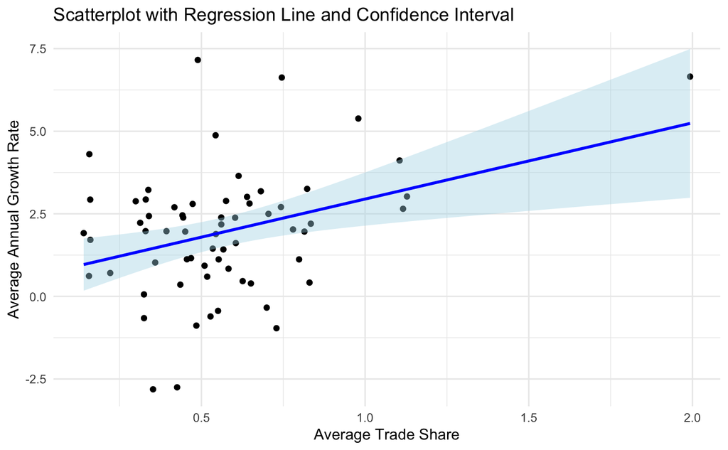

```r
# Scatterplot with regression line and confidence interval
ggplot(df, aes(x = tradeshare, y = growth)) +
  geom_point() +
  geom_smooth(method = "lm", se = TRUE, color = "blue", fill = "lightblue") +
  labs(title = "Scatterplot with Regression Line and Confidence Interval",
       x = "Average Trade Share",
       y = "Average Annual Growth Rate") +
  theme_minimal()
```

### Interpret the coefficients from the regression output.

Add a regression line to your scatterplot and include the confidence interval.

```r
# Linear Regression Model
model <- lm(growth ~ tradeshare, data = df)
# Summary of model
summary(model)
```

```
Call:
lm(formula = growth ~ tradeshare, data = df)

Residuals:
    Min      1Q  Median      3Q     Max
-4.3739 -0.8864  0.2329  0.9248  5.3889

Coefficients:
            Estimate Std. Error t value Pr(>|t|)
(Intercept)   0.6403     0.4900   1.307  0.19606
tradeshare    2.3064     0.7735   2.982  0.00407 **
---
Signif. codes:  0 ‘***’ 0.001 ‘**’ 0.01 ‘*’ 0.05 ‘.’ 0.1 ‘ ’ 1

Residual standard error: 1.79 on 63 degrees of freedom
Multiple R-squared:  0.1237,    Adjusted R-squared:  0.1098
F-statistic: 8.892 on 1 and 63 DF,  p-value: 0.00407
```

- The intercept shows that if the trade share were to equal to 0 the the growth rate would be 0.6403 The slope or the coefficient for trade share is 2.3064 which means that for every trade share increase of 1 the growth rate is expected to increase by 2.3064.
- The p-value of the trade share coefficient would be 0.004 which is less the 0.05 indicating that the relationship between trade share and growth rate is significant

## 5. Robustness of the Regression Model

Re-estimate the regression model by excluding the outlier identified earlier. Compare the regression coefficients and the predicted values for the outlier country with and without its inclusion in the sample. Discuss how the presence of the outlier affects the regression results and the robustness of the model.

- The removal of the outlier we can see changes that the p-value changes from 0.00407 to 0.0937 making the p-value greater than 0.05 which was making the relationship between trade share and growth becoming weaker and isn’t statistically significant. The significant impact that one country makes the data better suited to study versus relying on one point to make the biggest significance. The residuals of -4.4 and the max of 5.3 makes it so that the predictions have varying degrees, but comparing the one with and without the outlier isn’t as much of a difference of -4.3 to -4.4 and 5.38 to 5.37.

```r
# remove outlier from the data
df_no_outlier <- df %>% filter(country_name !="Malta")

# Re-estimate the linear regression model without the outlier
model_no_outlier <- lm(growth ~ tradeshare, data = df_no_outlier)

# View the summary of the model without the outlier
summary(model_no_outlier)
```

```
Call:
lm(formula = growth ~ tradeshare, data = df_no_outlier)

Residuals:
    Min      1Q  Median      3Q     Max
-4.4247 -0.9383  0.2091  0.9265  5.3776

Coefficients:
            Estimate Std. Error t value Pr(>|t|)
(Intercept)   0.9574     0.5804   1.650   0.1041
tradeshare    1.6809     0.9874   1.702   0.0937 .
---
Signif. codes:  0 ‘***’ 0.001 ‘**’ 0.01 ‘*’ 0.05 ‘.’ 0.1 ‘ ’ 1

Residual standard error: 1.789 on 62 degrees of freedom
Multiple R-squared:  0.04466,   Adjusted R-squared:  0.02925
F-statistic: 2.898 on 1 and 62 DF,  p-value: 0.09369
```

## 6. Prediction

Predict the growth rate for the outlier country using the regression model excluding the outlier. Compare this predicted value with the actual observed value. Discuss the implications of including or excluding outliers in regression analysis.

```r
malta <- df %>% filter(country_name == 'Malta')
predicted_growth_malta <- predict(model_no_outlier, newdata=malta_data)
actual_growth_malta <- malta_data$growth
print(paste('Predicted Growth Rate for Malta:', predicted_growth_malta))
```

```
[1] "Predicted Growth Rate for Malta: 4.30680769061919"
```

```r
print(paste('Actual Growth Rate for Malta:', actual_growth_malta))
```

```
[1] "Actual Growth Rate for Malta: 6.6528377532959"
```

The difference in the predicted versus the actual growth rate for Malta is much lower than what was the actual of 6.65% versus the predicted 4.31%. Taking Malta out of the model makes the model weaker in making predictions like Malta but having it makes the model more reliant on just one data point.